# Paged HTML Document

Jonathan Rossouw

4 December 2021

# 1 Introduction

The following is a study of the SA mid and long term bond yield spreads. The spreads are compared to each other, inflation, the USD ZAR Exchange rate, a selection of foreign bond yields, and a selection of volatility indices to give the movement in the yields context.

## 1.1 What are the yields

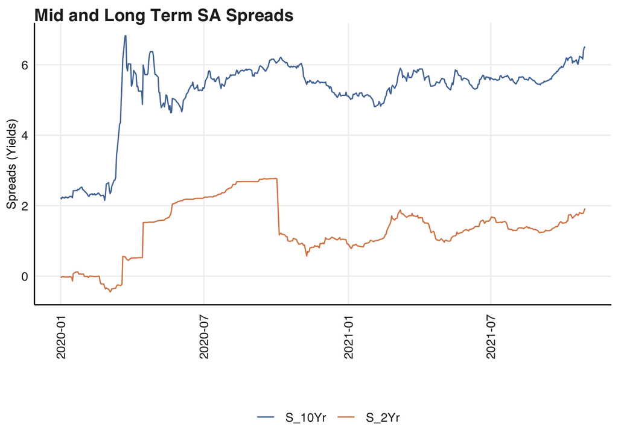

Clearly, there has been a sharp increase in the mid and long term spreads since the onset of COVID-19. While the mid spread has come down slightly since its high in late 2020, the long spread remains high.

## 1.2 Inflation

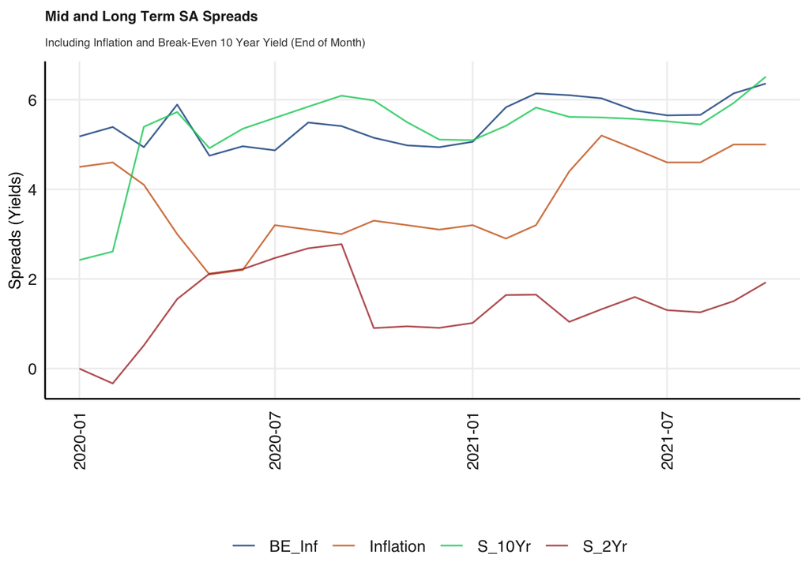

When including inflation on a monthly basis, inflation had been above the long spread before the pandemic but that has since reversed. Inflation remains below the long yield. The Break-Even inflation and long yield are tracking closely.

## 1.3 USD ZAR

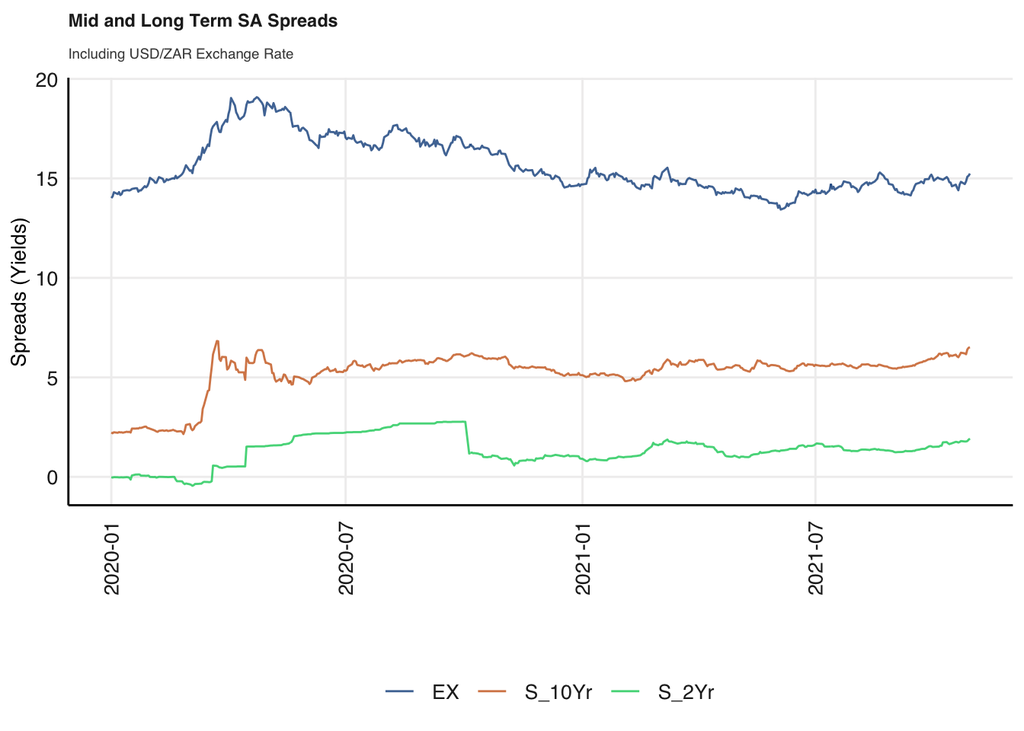

The initial run to safety following the onset of the pandemic saw a large depreciation in the Rand to USD. The spreads followed this pattern. Subsequently, while the Rand has appreciated, the spreads have remained high.

## 1.4 Other Yields

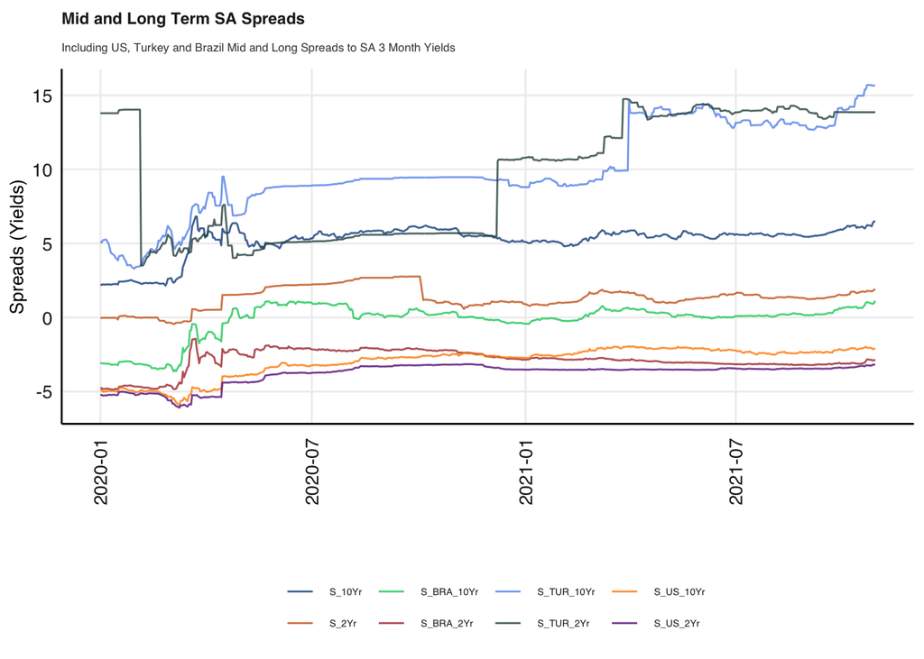

## 1.5 Volatility Indices

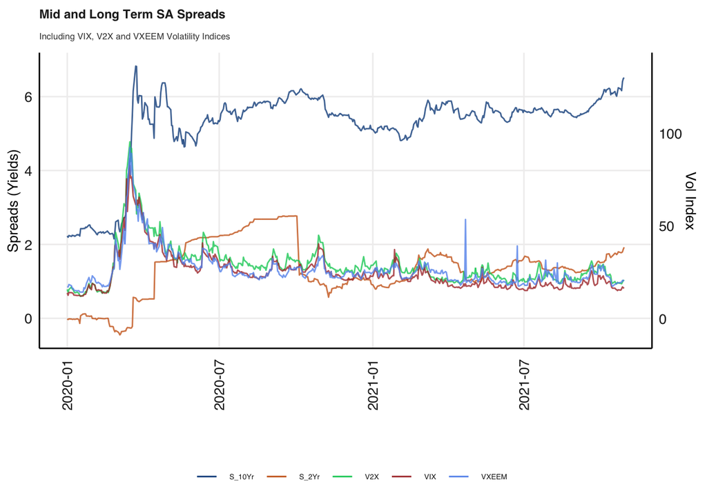

The outbreak of the pandemic was a major source of volality to the markets. This conincided with the sharp increase in the mid and long SA bond spreads. Since the initial scare, the volaility indecies have lower in volatility along with the decreased mid spread. However, the long spread remains high.

# 2 Conclusion